# R Notebook

```r
library(tidyverse)
library(janitor)
library(infer)
```

## 1.1

# Question1:

```r
glimpse(msleep)
```

[output not shown]

# Question 2:

Step 1: H0: mean_sleep_total == 7 Ha: mean_sleep_total != 7

Significance level for this test: 0.05

Step 2:

```r
observed_stat_sleep <- msleep %>%
  summarise(mean_sleep_total = mean(sleep_total))

observed_stat_sleep
```

| mean_sleep_total |
| --- |
| 10.43373 |

Step 3:

```r
null_distribution_sleep <- msleep%>%
  specify(response = sleep_total) %>%
  hypothesise(null = "point", mu =  7   ) %>%
  generate(reps = 2000, type = "bootstrap") %>%
  calculate(stat ="mean")
```

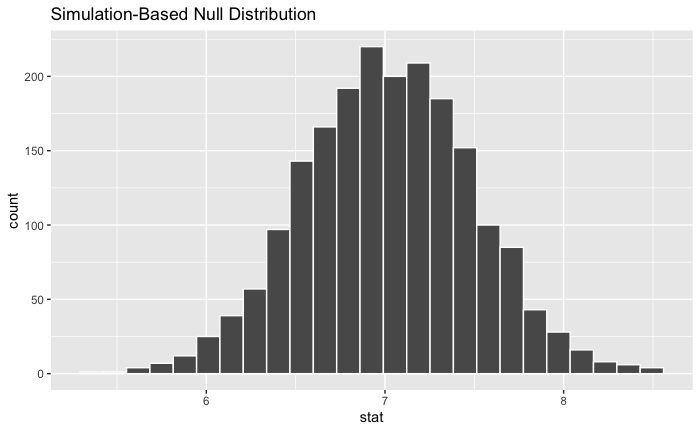

```r
null_distribution_sleep %>%
  visualise(bins = 25)
```

Step 4:

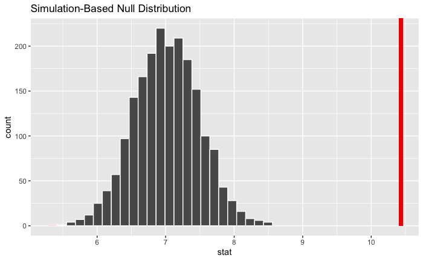

```r
null_distribution_sleep %>%
  visualise(bins = 25) +
  shade_p_value(obs_stat = observed_stat_sleep$mean_sleep_total,
                direction = "both")
```

Step 5:

```r
null_distribution_sleep %>%
 get_p_value(obs_stat = observed_stat_sleep$mean_sleep_total,
                direction = "both")
```

| p_value |
| --- |
| 0 |

Since the P value is 0 I would reject the HO and state the the average sleep for other animals is significantly different from other animals.

However the fact that I got 0 makes me question if I’ve made a mistake somewhere

# Question 3:

```r
diet_sleep <- msleep %>%
  filter(vore == "omni" | vore == "herbi")

diet_sleep
```

| name | genus | vore | order | conservation | sleep_total | sleep_rem | sleep_cycle | awake | brainwt | bodywt |
| --- | --- | --- | --- | --- | --- | --- | --- | --- | --- | --- |
| Owl monkey | Aotus | omni | Primates | NA | 17.0 | 1.8 | NA | 7.0 | 0.01550 | 0.480 |
| Mountain beaver | Aplodontia | herbi | Rodentia | nt | 14.4 | 2.4 | NA | 9.6 | NA | 1.350 |
| Greater short-tailed shrew | Blarina | omni | Soricomorpha | lc | 14.9 | 2.3 | 0.1333333 | 9.1 | 0.00029 | 0.019 |
| Cow | Bos | herbi | Artiodactyla | domesticated | 4.0 | 0.7 | 0.6666667 | 20.0 | 0.42300 | 600.000 |
| Three-toed sloth | Bradypus | herbi | Pilosa | NA | 14.4 | 2.2 | 0.7666667 | 9.6 | NA | 3.850 |
| Roe deer | Capreolus | herbi | Artiodactyla | lc | 3.0 | NA | NA | 21.0 | 0.09820 | 14.800 |
| Goat | Capri | herbi | Artiodactyla | lc | 5.3 | 0.6 | NA | 18.7 | 0.11500 | 33.500 |
| Guinea pig | Cavis | herbi | Rodentia | domesticated | 9.4 | 0.8 | 0.2166667 | 14.6 | 0.00550 | 0.728 |
| Grivet | Cercopithecus | omni | Primates | lc | 10.0 | 0.7 | NA | 14.0 | NA | 4.750 |
| Chinchilla | Chinchilla | herbi | Rodentia | domesticated | 12.5 | 1.5 | 0.1166667 | 11.5 | 0.00640 | 0.420 |

[output cut: 42 more lines]

H0: Mean sleep omnivore - mean sleep herbivore == 0 Ha: Mean sleep omnivore - mean sleep herbivore > 0

Significance level: 0.05

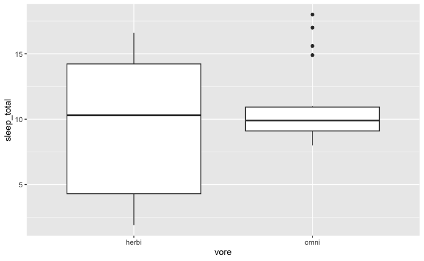

```r
diet_sleep %>%
  ggplot(aes(y = sleep_total, x = vore)) +
  geom_boxplot()
```

```r
observed_stat_diet <- diet_sleep %>%
  specify(response = sleep_total, explanatory = vore) %>%
  calculate(stat = "diff in means", order = c("omni", "herbi"))

observed_stat_diet
```

```
Response: sleep_total (numeric)
Explanatory: vore (factor)
```

| stat |
| --- |
| 1.415625 |

```r
null_distribution_diet <- diet_sleep %>%
  specify(response = sleep_total, explanatory = vore) %>%
  hypothesise(null = "independence") %>%
  generate(reps = 1000, type = "permute") %>%
  calculate(stat = "diff in means", order = c("omni", "herbi"))

head(null_distribution)
```

```
Response: sleep_total (numeric)
Explanatory: vore (factor)
Null Hypothesis: independence
```

| replicate | stat |
| --- | --- |
| 1 | -0.461250 |
| 2 | 0.205000 |
| 3 | 1.496875 |
| 4 | -0.534375 |
| 5 | 0.985000 |
| 6 | 1.261250 |

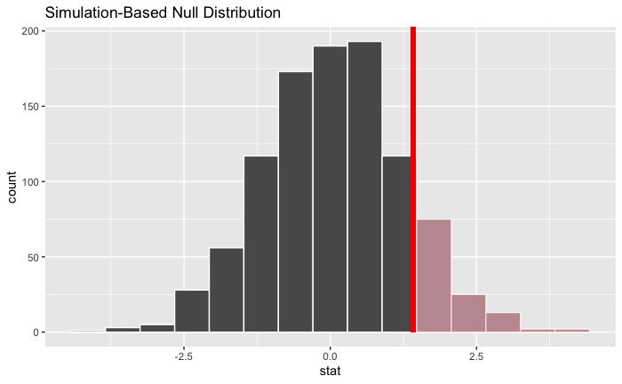

```r
null_distribution_diet %>%
  visualise() +
  shade_p_value(obs_stat = observed_stat_diet$stat,
                direction = "greater")
```

```r
null_distribution_diet %>%
  get_p_value(obs_stat = observed_stat_diet$stat,
                direction = "greater")
```

| p_value |
| --- |
| 0.135 |

threshold was 0.05. p = 0.135 which is higher than our threshold

Failing to reject H0 - we cannot say that Mean sleep omnivore - mean sleep herbivore == 0

# Question 4:

```r
domesticate_vs_wild <- msleep %>%
  mutate(is_domesticated = ifelse(conservation == "domesticated", "domesticated", "wild")) %>%
  drop_na(is_domesticated)

domesticate_vs_wild
```

[output not shown]

H0: prop_domesticated_animal == 0.05 Ha: prop_domesticated_animal > 0.05

alpha (significance level) = 0.05

```r
observed_stat_domesticated <- domesticate_vs_wild %>%
  summarise(prop = sum(is_domesticated == "domesticated")/ n())

observed_stat_domesticated
```

| prop |
| --- |
| 0.1851852 |

```r
null_distribution_domesticated <- domesticate_vs_wild %>%
  specify(response = is_domesticated, success = "domesticated") %>%
  hypothesise(null = "point", p = 0.05) %>%
  generate(reps = 2000, type = "draw") %>%
  calculate(stat = "prop")
```

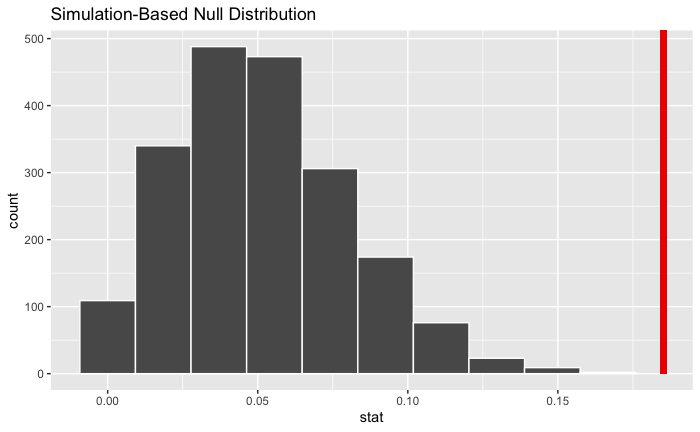

```r
null_distribution_domesticated %>%
  visualise(bins = 10) +
  shade_p_value(obs_stat = observed_stat_domesticated$prop,
                direction = "right")
```

```r
null_distribution_domesticated %>%
  get_p_value(obs_stat = observed_stat_domesticated$prop,
                direction = "right")
```

| p_value |
| --- |
| 0 |

threshold was 0.05. p = 0 which is lower than our threshold

Therefore we can reject H0 and assume that the proportion of domesticated animals is greater than 5%

(Think I have also done this wrong as I think it’s very unlikely that both P values would be 0)

## 1.2

# Question 1:

- Test: One-sample proportion test
- H0: p < = 0.4 (less than or equal to 40% of the town’s population knows of the coffee shop) Ha: p > 0.4 (more than 40% of the town’s population knows of the coffee shop)
- Method: Draw

# Question 2:

- Test: Two-sample proportion test
- H0: pA <= pB (the proportion of clicks for the banner in group A is less than or equal to the proportion of clicks for the banner in group B) Ha: pA > pB (the proportion of clicks in group A is greater than the proportion of clicks for the banner in group B)
- Method: Draw

# Question 3:

- Test: One-sample t-test
- H0: mean width of car parts == 145mm Ha: mean width of car parts != 145mm
- Method: Bootstrap

## 1.3

# Question 1:

Coffee shop problem. Significance level: 0.05, calculated p-value: 0.07

Since the p-value of 0.07 is greater than the significance level of 0.05 we cannot reject The H0 (less than or equal to 40% of the town’s population knows of the coffee shop)

# Question 2:

Website company problem. Significance level: 0.01, p-value: 0.006

Since the p-value 0.006 is less than the Significance level: 0.01 we can reject the H0 (the proportion of clicks for the banner in group A is less than or equal to the proportion of clicks for the banner in group B) and assume the Ha to be true.

Therefore, the website company should consider positioning the banner at the top of the page for better results.

# Question 3:

Manufacturing company problem. Significance level: 0.05, p-value: 0.55